# Understanding and Predicting Credit Card Churn: An In-Depth Analysis of Customer Attrition in The Credit Card Industry

#### **Authors**: Smit Pancholi, Gouri Dumale, Swathi KR, Abhradeep Das

#### **Keywords**: Customer Churn, Logistic Regression, Random Forest, Decision Tree

# Abstract

Our team is dedicated to the project “Understanding and Predicting Credit Card Churn: A Detailed Examination of Customer Loss in the Credit Card Industry.” We’re deeply immersed in investigating interactions involving 10,127 clients and a financial institution, utilizing a dataset rich in diverse client attributes, such as age, income categories, and credit card preferences. Our primary goal is to decipher distinct customer segments through meticulous segmentation techniques, comprehending how these attributes converge to form specific client clusters. Concurrently, our analysis involves scrutinizing transactional patterns across various income brackets, providing valuable insights into typical client behaviors. Furthermore, we’re committed to understanding the complex relationship between a client’s average utilization ratio and their credit limit, emphasizing responsible credit utilization practices. Identifying key factors influencing client attrition is central to our objectives, intending to categorize these factors using variables like age, credit utilization, or contact frequency. Additionally, our exploration extends to studying the correlation between client income categories and attrition rates, focusing on devising tailored retention strategies, particularly for clients in lower income brackets. Leveraging the “Credit Card Churn” dataset hosted on GitHub, our research enables a comprehensive exploration of client profiles and behaviors. We foresee that the insights gleaned will significantly enhance the banking sector, providing essential guidance to financial institutions to better cater to their clients’ needs and preferences within a framework of 10,127 interactions.

# Introduction

Presently, the market undergoes continual change and fierce competition, largely fueled by the proliferation of various service providers, notably within the global banking realm. One of the primary challenges faced by this sector revolves around adapting to shifts in customer behavior. In all industries, but particularly within customer-centric sectors like banking, customers are the bedrock. Banks, entrusted with managing deposits, investments, and loans, understand the direct correlation between retaining long-term customers and bolstering profits. Hence, preventing customer attrition is a critical goal for banks [1-4]. As per the Harvard Business Review, even a 5% decrease in customers can significantly elevate company profits, with potential increases ranging between 25% and 85% [4,5]. Consequently, acknowledging customers’ pivotal role as substantial assets with profound impacts on a bank’s profitability, modern banking enterprises prioritize five fundamental pillars: capital, liquidity, risk management, asset management, and customer management [6,7]. A targeted focus on these pillars is indispensable for management seeking to effectively optimize a bank’s profitability [7,8].

Thus, the departure of customers to rival institutions, known as customer attrition or churn, poses a significant and underlying concern for banks, leading to financial losses. Therefore, the primary aim of the project is to acquire an in-depth comprehension of diverse customer segments, their transactional behaviors across varying income brackets, the correlation between their credit utilization and credit limits, the causes underlying customer attrition, and strategies to retain clients, particularly those within lower income brackets. The project revolves around a dataset encompassing over 10,000 individuals and their interactions, offering valuable insights into customer behavior and preferences. This extensive dataset contains intricate demographic details like age, gender, educational background, marital status, and income categories. Moreover, it delves into credit card usage patterns, providing insights into credit limits, transactional patterns, and card categories. Beyond the surface, this dataset delves into banking relationships, including the total relationship count and periods of inactivity. The wealth of data available presents a unique opportunity to unveil the complexities of customer profiles and behaviors, laying the groundwork for a comprehensive examination of elements impacting banking relationships, credit card usage trends, and notably, customer attrition.

# Data and Methodology

The project, titled “Understanding and Predicting Credit Card Churn,” centers around a dataset sourced from Kaggle, offering valuable insights into the financial behaviors of 10,127 clients and their engagements with a financial institution. This dataset comprises a diverse array of client attributes, including age, gender, education level, marital status, and income categories. It provides a comprehensive view of credit card usage patterns, covering aspects like credit limits, transaction amounts, card categories, and sheds light on banking relationships such as the total number of relationships and inactive periods.

To ensure the data’s readiness, the team has meticulously executed data preprocessing tasks. These tasks involve rigorous verification of data types, meticulous handling of null values, and organizing the data for subsequent analysis. Methodologically, a spectrum of statistical techniques, encompassing logistic regression, decision trees, random forest, and correlation analyses, has been applied to unveil latent patterns, correlations, and unique attributes within the dataset.

The research objectives pivot around customer segmentation, analyzing transactional behaviors across diverse income categories, identifying key factors contributing to client attrition, comprehending credit utilization patterns, and probing the correlation between income categories and client churn. The ultimate aim of this project is to derive actionable insights capable of guiding strategic decisions and ultimately enhancing the overall banking experience.

## *Summary Statistics*

```
## 'data.frame':    10127 obs. of  20 variables:
##  $ Attrition_Flag          : chr  "Existing Customer" "Existing Customer" "Existing Customer" "Existing Customer" ...
##  $ Customer_Age            : int  45 49 51 40 40 44 51 32 37 48 ...
##  $ Gender                  : chr  "M" "F" "M" "F" ...
##  $ Dependent_count         : int  3 5 3 4 3 2 4 0 3 2 ...
##  $ Education_Level         : chr  "High School" "Graduate" "Graduate" "High School" ...
##  $ Marital_Status          : chr  "Married" "Single" "Married" "Unknown" ...
##  $ Income_Category         : chr  "$60K - $80K" "Less than $40K" "$80K - $120K" "Less than $40K" ...
##  $ Card_Category           : chr  "Blue" "Blue" "Blue" "Blue" ...
##  $ Months_on_book          : int  39 44 36 34 21 36 46 27 36 36 ...
##  $ Total_Relationship_Count: int  5 6 4 3 5 3 6 2 5 6 ...
##  $ Months_Inactive_12_mon  : int  1 1 1 4 1 1 1 2 2 3 ...
##  $ Contacts_Count_12_mon   : int  3 2 0 1 0 2 3 2 0 3 ...
##  $ Credit_Limit            : num  12691 8256 3418 3313 4716 ...
##  $ Total_Revolving_Bal     : int  777 864 0 2517 0 1247 2264 1396 2517 1677 ...
##  $ Avg_Open_To_Buy         : num  11914 7392 3418 796 4716 ...
##  $ Total_Amt_Chng_Q4_Q1    : num  1.33 1.54 2.59 1.4 2.17 ...
##  $ Total_Trans_Amt         : int  1144 1291 1887 1171 816 1088 1330 1538 1350 1441 ...
##  $ Total_Trans_Ct          : int  42 33 20 20 28 24 31 36 24 32 ...
##  $ Total_Ct_Chng_Q4_Q1     : num  1.62 3.71 2.33 2.33 2.5 ...
##  $ Avg_Utilization_Ratio   : num  0.061 0.105 0 0.76 0 0.311 0.066 0.048 0.113 0.144 ...
```

```
##  Attrition_Flag      Customer_Age     Gender          Dependent_count
##  Length:10127       Min.   :26.0   Length:10127       Min.   :0.00
##  Class :character   1st Qu.:41.0   Class :character   1st Qu.:1.00
##  Mode  :character   Median :46.0   Mode  :character   Median :2.00
##                     Mean   :46.3                      Mean   :2.35
##                     3rd Qu.:52.0                      3rd Qu.:3.00
##                     Max.   :73.0                      Max.   :5.00
##  Education_Level    Marital_Status     Income_Category    Card_Category
##  Length:10127       Length:10127       Length:10127       Length:10127
##  Class :character   Class :character   Class :character   Class :character
##  Mode  :character   Mode  :character   Mode  :character   Mode  :character
##
##
##
##  Months_on_book Total_Relationship_Count Months_Inactive_12_mon
##  Min.   :13.0   Min.   :1.00             Min.   :0.00
##  1st Qu.:31.0   1st Qu.:3.00             1st Qu.:2.00
##  Median :36.0   Median :4.00             Median :2.00
##  Mean   :35.9   Mean   :3.81             Mean   :2.34
##  3rd Qu.:40.0   3rd Qu.:5.00             3rd Qu.:3.00
##  Max.   :56.0   Max.   :6.00             Max.   :6.00
##  Contacts_Count_12_mon  Credit_Limit   Total_Revolving_Bal Avg_Open_To_Buy
##  Min.   :0.00          Min.   : 1438   Min.   :   0        Min.   :    3
##  1st Qu.:2.00          1st Qu.: 2555   1st Qu.: 359        1st Qu.: 1324
##  Median :2.00          Median : 4549   Median :1276        Median : 3474
##  Mean   :2.46          Mean   : 8632   Mean   :1163        Mean   : 7469
##  3rd Qu.:3.00          3rd Qu.:11068   3rd Qu.:1784        3rd Qu.: 9859
##  Max.   :6.00          Max.   :34516   Max.   :2517        Max.   :34516
##  Total_Amt_Chng_Q4_Q1 Total_Trans_Amt Total_Trans_Ct  Total_Ct_Chng_Q4_Q1
##  Min.   :0.00         Min.   :  510   Min.   : 10.0   Min.   :0.00
##  1st Qu.:0.63         1st Qu.: 2156   1st Qu.: 45.0   1st Qu.:0.58
##  Median :0.74         Median : 3899   Median : 67.0   Median :0.70
##  Mean   :0.76         Mean   : 4404   Mean   : 64.9   Mean   :0.71
##  3rd Qu.:0.86         3rd Qu.: 4741   3rd Qu.: 81.0   3rd Qu.:0.82
##  Max.   :3.40         Max.   :18484   Max.   :139.0   Max.   :3.71
##  Avg_Utilization_Ratio
##  Min.   :0.000
##  1st Qu.:0.023
##  Median :0.176
##  Mean   :0.275
##  3rd Qu.:0.503
##  Max.   :0.999
```

## *Logistic Regression*

Logistic regression is a statistical technique used for binary classification problems, where the target variable is categorical and has two possible outcomes. Unlike linear regression, which predicts continuous values, logistic regression models the probability that an input belongs to a particular category using the logistic or sigmoid function. This function ensures that the output is bounded between 0 and 1, representing probabilities.One of the distinguishing characteristics of logistic regression is its ability to provide probabilistic outputs, enabling not only class predictions but also an estimation of confidence in those predictions. This method establishes a linear decision boundary, making it suitable for problems where a straight line or plane can effectively separate the classes. However, logistic regression assumes a linear relationship between the independent variables and the log-odds of the dependent variable, which might limit its performance with complex, nonlinear relationships without additional feature engineering.Extensions of logistic regression include multinomial logistic regression for multiclass classification problems and regularization techniques like L1 and L2 regularization to prevent overfitting. Evaluation metrics like accuracy, precision, recall, F1-score, and ROC-AUC are commonly used to assess the model’s performance.

## *Decision Tree*

Decision trees are versatile and intuitive predictive modeling tools used in machine learning for both classification and regression tasks. They mimic human decision-making by creating a tree-like structure, where each internal node represents a feature, each branch represents a decision rule based on that feature, and each leaf node represents the outcome or prediction.Decision trees perform these splits using various algorithms such as ID3, C4.5, CART (Classification and Regression Trees), or others. One common metric used for determining the best split is the Gini impurity (for classification) or mean squared error (for regression), which measures the degree of impurity or uncertainty in the dataset.Decision trees offer several advantages, including their interpretability, as the resulting tree structure is easy to understand and visualize. They can handle both numerical and categorical data and implicitly perform feature selection by identifying the most informative features at the top of the tree.

## *Random Forest*

Random Forest is a versatile and powerful ensemble learning method used in both classification and regression tasks within machine learning. It operates by constructing multiple decision trees during training and outputs the mode of the classes (for classification) or the mean prediction (for regression) of individual trees. The fundamental principle of Random Forest lies in creating a forest of decision trees, each of which is trained on a random subset of the training data and a random subset of the features. This randomness in the training process helps to prevent overfitting, enhance model generalization, and reduce variance, making it more robust and less sensitive to noise in the dataset.During the prediction phase, for classification tasks, the Random Forest aggregates the predictions from each individual tree and outputs the class that receives the most votes (mode). For regression tasks, it computes the mean prediction from all trees. This averaging process mitigates the tendency of individual decision trees to overfit the data and provides a more stable and accurate prediction. Random Forests offer several advantages. They are relatively easy to use, less prone to overfitting compared to individual decision trees, and can handle large datasets with high dimensionality. Moreover, they provide feature importance scores, which indicate the contribution of each feature in the model’s predictive capability, aiding in feature selection and understanding the data. However, Random Forests are not immune to drawbacks. They can be computationally expensive, especially with a large number of trees or features. Additionally, while they usually offer excellent performance, they might not be the best choice for highly imbalanced datasets or datasets with strong linear relationships among features.

# Results

This section presents the outcomes and findings obtained from employing various machine learning algorithms for predicting credit card churn. The primary objective of this study was to develop models capable of accurately identifying potential churners in the credit card customer base. Exploratory Data Analysis (EDA) and correlation analysis were conducted to gain insights into the dataset’s characteristics and feature relationships. Additionally, three distinct machine learning models, namely Random Forest, Decision Tree, and Logistic Regression, were utilized for this predictive analysis.

## Exploratory Data Analysis

[figure not shown]

**Figure 1.**

[figure not shown]

**Figure 2.**

[figure not shown]

**Figure 3.**

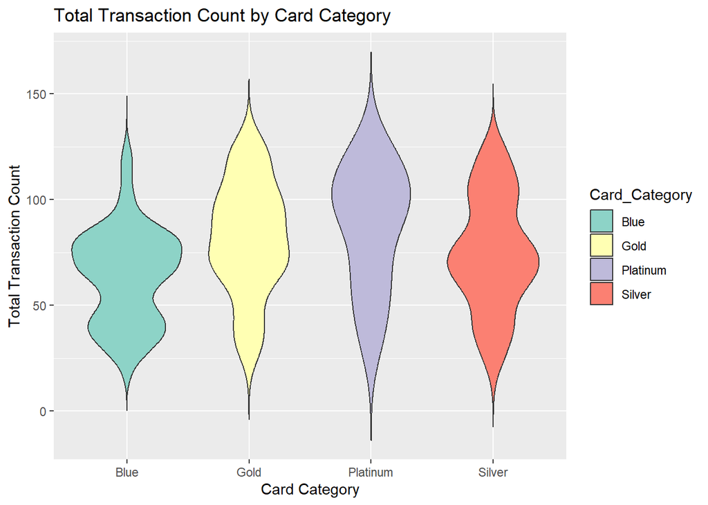

**Figure 4.**

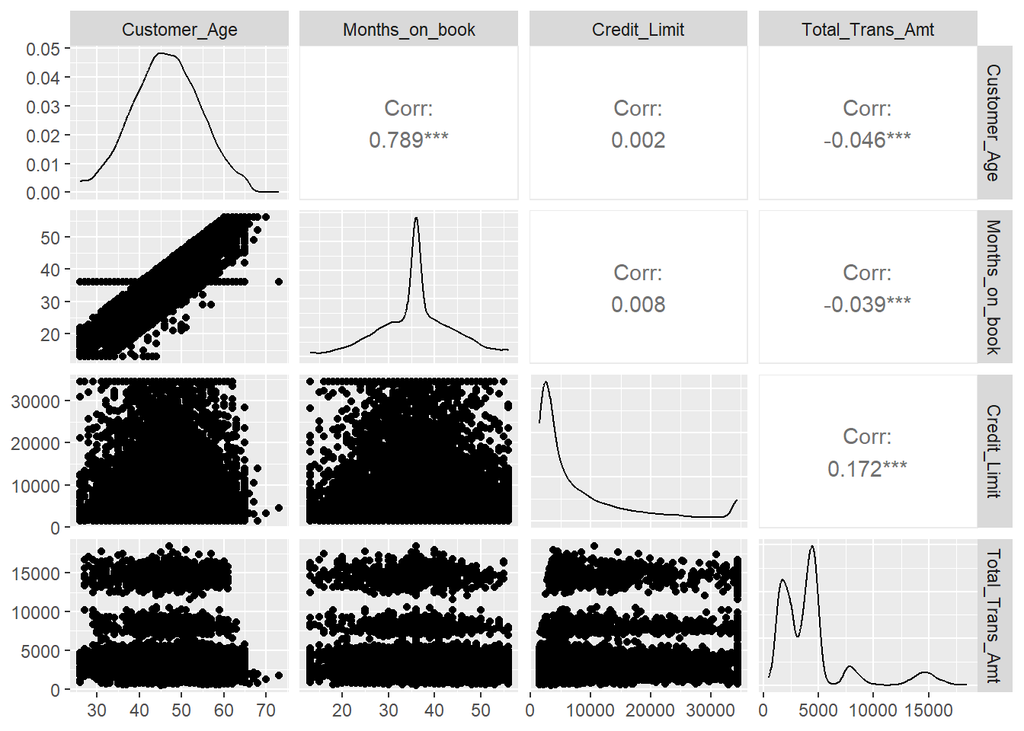

**Figure 5.**

Figure 5 presents a matrix of scatter plots, histograms, and correlation coefficients, providing a comprehensive visual representation of the relationships between multiple variables within a dataset. This visualization, often known as a pairs plot or a scatterplot matrix, offers valuable insights into the pairwise connections and linear correlations among various variables. The diagonal plots in the matrix display histograms representing the distribution of individual variables. For instance, the histogram labeled “Customer_Age” showcases the distribution of customer ages in the dataset, while other histograms along the diagonal illustrate the distributions of “Months_on_book,” “Credit_Limit,” and “Total_Trans_Amt.” The correlation between “Customer_Age” and “Months_on_book” yields a coefficient of 0.789, indicating a strong positive correlation. This suggests that as a customer’s age increases, the duration of their account tenure tends to increase as well, with a high level of statistical significance. Regarding “Credit_Limit” and “Total_Trans_Amt,” the correlation coefficient of 0.172 suggests a weak positive correlation. This implies that while there’s a tendency for higher credit limits to correspond with higher total transaction amounts, the relationship is not notably strong. An interesting observation arises from the correlation between “Customer_Age” and “Total_Trans_Amt,” yielding a correlation coefficient of -0.046. Despite being statistically significant, the extremely weak negative correlation implies that while there’s a minimal tendency for older customers to have slightly lower total transaction amounts, this relationship might not hold practical significance due to its proximity to zero.

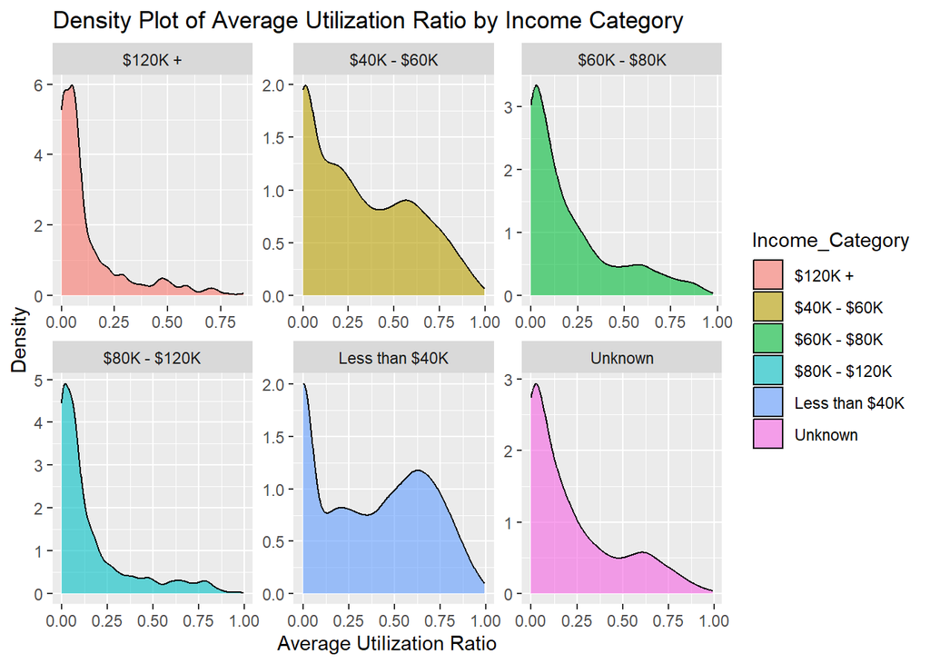

**Figure 6.**

Figure 6 illustrates a set of density plots, each depicting the distribution of the average utilization ratio across various income categories. These density plots offer insights into the utilization behavior concerning credit among different income brackets, providing a nuanced understanding of how individuals in distinct income groups manage their available credit. Each density plot corresponds to a specific income category, distinguished by different colors as depicted in the legend. The x-axis represents the average utilization ratio, a financial metric indicating the proportion of available credit being utilized by individuals. Meanwhile, the y-axis represents the density of data points, showcasing the concentration of observations at different utilization ratio levels. The “$120K+” category (red) demonstrates a prominent peak at a low utilization ratio, suggesting that individuals with higher incomes tend to maintain a notably lower credit utilization ratio. This peak implies that most high-income earners effectively manage and utilize a smaller proportion of their available credit. Both the “$40K - $60K” (yellow) and “$60K - $80K” (green) income categories display peaks at lower utilization ratios as well. However, these categories exhibit wider distributions, indicating more variability in credit utilization within these income brackets. Similarly, the “$80K - $120K” category (cyan) mirrors the trend of having a majority of individuals maintaining a low utilization ratio, aligning with prudent credit utilization practices. In contrast, the “Less than $40K” category (blue) shows a wider distribution, signifying a more diverse range of utilization ratios among lower-income earners. This suggests a broader spectrum of credit usage patterns within this income group. The “Unknown” income category (pink) depicts a substantial number of individuals spread across various utilization ratios, with a peak observed at a lower ratio. This suggests a diverse range of credit utilization behaviors within this category, with a considerable portion exhibiting lower credit utilization.

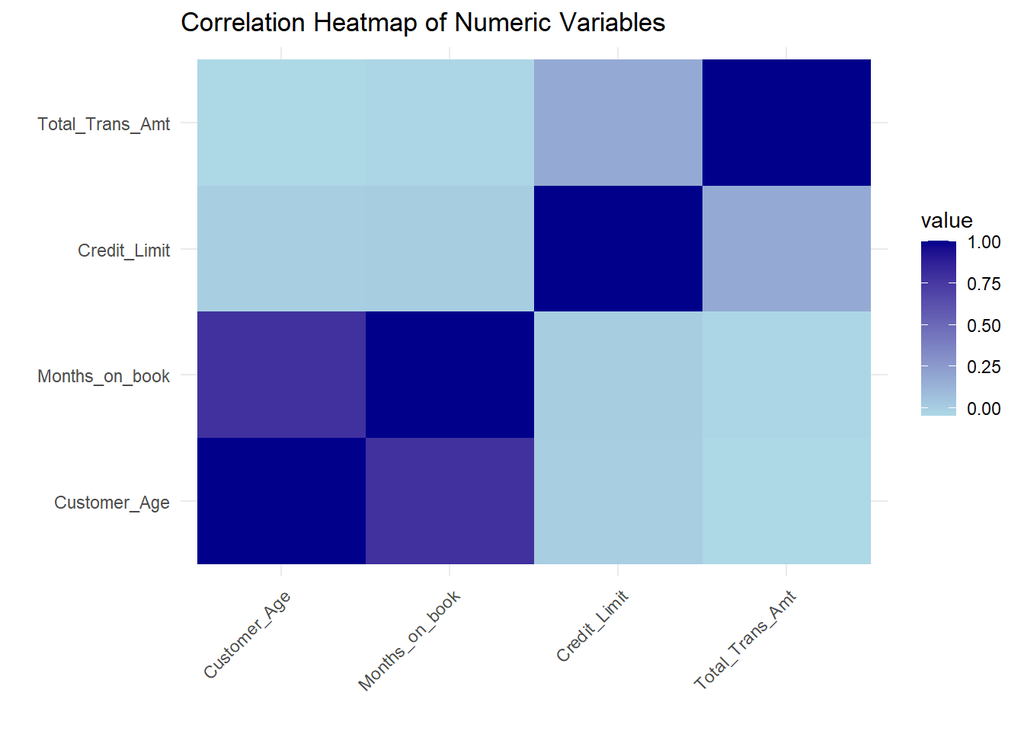

**Figure 7.**

## Random Forest

```
##                 Length Class  Mode
## call                4  -none- call
## type                1  -none- character
## predicted        8101  factor numeric
## err.rate         1500  -none- numeric
## confusion           6  -none- numeric
## votes           16202  matrix numeric
## oob.times        8101  -none- numeric
## classes             2  -none- character
## importance         19  -none- numeric
## importanceSD        0  -none- NULL
## localImportance     0  -none- NULL
## proximity           0  -none- NULL
## ntree               1  -none- numeric
## mtry                1  -none- numeric
## forest             14  -none- list
## y                8101  factor numeric
## test                0  -none- NULL
## inbag               0  -none- NULL
## terms               3  terms  call
```

```
##
## Call:
##  randomForest(formula = Attrition_Flag ~ ., data = training_reg,      ntree = 500)
##                Type of random forest: classification
##                      Number of trees: 500
## No. of variables tried at each split: 4
##
##         OOB estimate of  error rate: 3.67%
## Confusion matrix:
##                   Attrited Customer Existing Customer class.error
## Attrited Customer              1104               218      0.1649
## Existing Customer                79              6700      0.0117
```

```
## Random Forest Accuracy: 0.968
```

```
## Precision: 0.944
```

```
## Recall: 0.836
```

```
## F1 Score: 0.887
```

```
## True Positives: 1706
```

```
## False Positives: 15
```

```
## False Negatives: 50
```

```
## True Negatives: 255
```

## Logistic Regression Model

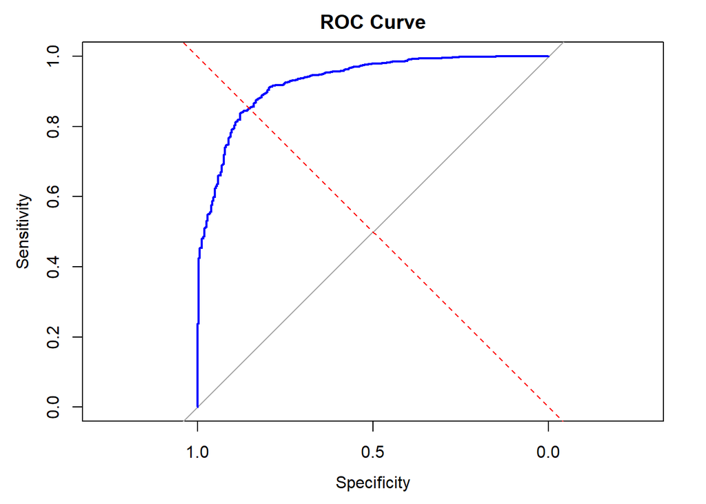

**Figure 8.**

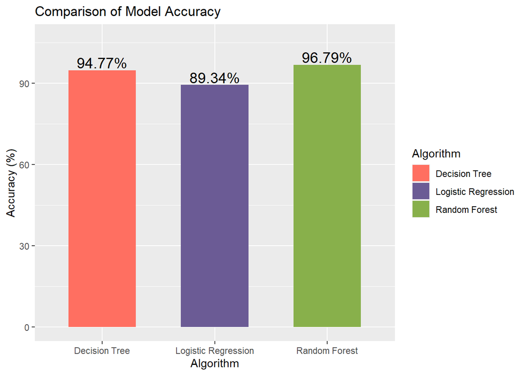

**Figure 9.**

The provided bar chart presents a comparative analysis of three distinct machine learning models: Decision Tree, Logistic Regression, and Random Forest. Each bar on the chart signifies the accuracy percentage achieved by a specific algorithm. The y-axis illustrates the accuracy percentages of the models, while the x-axis categorizes the types of algorithms utilized. The height of each bar corresponds to the accuracy percentage, explicitly labeled atop each bar. The colors red, purple, and green are indicative of the Decision Tree, Logistic Regression, and Random Forest models, respectively. According to the data showcased on the chart, the Decision Tree model achieves an accuracy of 94.77%. This model, known for its interpretability, partitions data based on different attributes to formulate decision rules for predicting outcomes. Logistic Regression, with an accuracy of 89.34%, estimates the probability of an instance belonging to a specific class, assuming a linear relationship between input features and the target variable. Meanwhile, the Random Forest model demonstrates the highest accuracy of 96.79%. Random Forest, an ensemble learning technique that amalgamates multiple decision trees, provides predictions by aggregating outcomes from several individual trees. Upon scrutinizing the results, it is evident that, in this specific scenario, the Random Forest model outperforms the other two models concerning accuracy. This superior performance could be attributed to the Random Forest’s ability to capture intricate relationships within the data, handle outliers adeptly, and mitigate overfitting by utilizing an ensemble of decision trees. Accuracy, a pivotal metric for evaluating classification models, signifies the proportion of correct predictions out of the total predictions made by the model. Conclusively, based on the accuracy percentages depicted in the chart, the Random Forest model emerges as the most accurate among the three models for predicting outcomes in this particular context. Nonetheless, comprehensive assessment and consideration of other metrics might be necessary to ascertain the model’s suitability for addressing the specific requirements of the given problem statement.

# Conclusion

In conclusion, this research explored and compared the efficacy of three distinct machine learning models: Decision Tree, Logistic Regression, and Random Forest, in predicting card churn attrition within the banking sector. These models were evaluated based on their accuracy metrics obtained from a comprehensive dataset. The Decision Tree model exhibited a commendable accuracy of 94.77%, showcasing its capability to form intuitive decision rules based on feature attributes. Logistic Regression, with an accuracy of 89.34%, performed reasonably well by estimating the probability of churn based on linear relationships between predictors and the target variable. However, the Random Forest model surpassed the others with the highest accuracy of 96.79%, indicating its robustness in capturing intricate data patterns through an ensemble approach. The outcomes gleaned from this study suggest that, in this specific banking context, the Random Forest model emerges as the most effective predictor of card churn attrition. Nevertheless, while accuracy serves as a primary metric for model evaluation, further analysis encompassing other performance metrics, such as precision, recall, and F1 score, could provide a more comprehensive understanding of each model’s predictive capability. Furthermore, considering the business implications and interpretability of models is crucial in real-world applications, where Decision Trees could offer a more explainable approach compared to ensemble models like Random Forest. Looking ahead, the predictive power of machine learning models, particularly the Random Forest, signifies their potential in aiding banking institutions to proactively identify customers at risk of card churn attrition. Leveraging these models, financial institutions could employ targeted retention strategies, personalized incentives, or tailored customer engagement initiatives aimed at reducing attrition rates and enhancing customer retention. This proactive approach not only helps in mitigating revenue loss associated with churn but also fosters customer loyalty and satisfaction, ultimately contributing to sustained business growth. However, it’s important to note that while these models exhibit promising accuracy rates, their performance might vary based on evolving customer behaviors, changing market dynamics, or shifts in banking policies. Continual monitoring, retraining, and refinement of these models are imperative to ensure their adaptability and reliability in a dynamic banking landscape. In summary, the exploration and comparison of these machine learning models shed light on their potential utility in predicting card churn attrition within the banking sector. The Random Forest model, with its superior accuracy, emerges as a formidable tool for proactive churn prediction, providing financial institutions with actionable insights to curtail attrition rates and foster long-term customer relationships. However, deploying these models in practice warrants a balanced consideration of not only predictive performance but also interpretability and adaptability in real-world banking scenarios.

# References

1. Jagadeesan, A.P. (2020). Bank customer retention prediction and customer ranking based on deep neural networks. International Journal of Scientific Development Research, 5, 444–449.
2. Amuda, K.A., & Adeyemo, A.B. (2019). Customer churn prediction in a financial institution using artificial neural networks. arXiv, arXiv:1912.11346.
3. Kim, S., Shin, K.-S., & Park, K. (2005). An application of support vector machines for customer churn analysis: Credit card case. In Proceedings of the International Conference on Natural Computation (pp. 636–647). Springer.
4. Kumar, D.A., & Ravi, V. (2008). Predicting credit card customer churn in banks using data mining. *International Journal of Data Analysis and Technology Strategies, 1*, 4–28. https://doi.org/10.1504/IJDATS.2008.02002
5. Keramati, A., Ghaneei, H., & Mirmohammadi, S.M. (2016). Developing a prediction model for customer churn from electronic banking services using data mining. Financial Innovation, 2, 10. http://doi.org/10.1186/s40854-016-0029-6
6. Bastan, M., Akbarpour, S., & Ahmadvand, A. (2016). Business dynamics of Iranian commercial banks. In Proceedings of the 34th International Conference of the System Dynamics Society, Delft, The Netherlands.
7. Bastan, M., Bagheri Mazrae, M., Ahmadvand, A. (2016). Dynamics of banking soundness based on CAMELS Rating system. In Proceedings of the 34th International Conference of the System Dynamics Society, Delft, The Netherlands.
8. Iranmanesh, S.H., Hamid, M., Bastan, M., Hamed Shakouri, G., & Nasiri, M.M. (2019). Customer churn prediction using artificial neural network: An analytical CRM application. In Proceedings of the International Conference on Industrial Engineering and Operations Management, Bangkok, Thailand (pp. 23–26).